# Comparison with Alternatives

Gilles Colling

2026-09-30

## Overview

This vignette compares couplr’s approach to matching with established R packages: 1. **MatchIt** - The most popular matching package in R

2. **optmatch** - Optimal full matching with constraints
3. **designmatch** - Optimization-based matching with balance constraints
4. **Matching** - Genetic matching and multivariate matching

Each comparison examines algorithmic differences, API design, performance characteristics, and appropriate use cases. We use simulated observational data to demonstrate practical differences.

**Prerequisites**: Familiarity with `vignette("matching-workflows")` for couplr’s matching approach.

## Evaluation Dataset

We simulate a job training evaluation scenario with selection bias:

```r
set.seed(42)

# Treatment group: younger, more educated, higher prior earnings
treatment <- tibble(

  id = 1:200,
  age = rnorm(200, mean = 35, sd = 8),
  education = rnorm(200, mean = 14, sd = 2),
  prior_earnings = rnorm(200, mean = 40000, sd = 12000),
  employed = rbinom(200, 1, 0.7),
  group = "treatment"
)

# Control group: older, less educated, lower prior earnings (selection bias)
control <- tibble(
  id = 201:700,
  age = rnorm(500, mean = 45, sd = 12),
  education = rnorm(500, mean = 12, sd = 3),
  prior_earnings = rnorm(500, mean = 32000, sd = 15000),
  employed = rbinom(500, 1, 0.5),
  group = "control"
)

# Combine for packages that expect single data frame
combined <- bind_rows(treatment, control) |>
  mutate(treated = as.integer(group == "treatment"))

cat("Treatment units:", nrow(treatment), "\n")
```

```
#> Treatment units: 200
```

```r
cat("Control units:", nrow(control), "\n")
```

```
#> Control units: 500
```

```r
# Baseline imbalance
vars <- c("age", "education", "prior_earnings", "employed")
for (v in vars) {
  diff <- mean(treatment[[v]]) - mean(control[[v]])
  pooled_sd <- sqrt((var(treatment[[v]]) + var(control[[v]])) / 2)
  std_diff <- diff / pooled_sd
  cat(sprintf("%s: std diff = %.3f\n", v, std_diff))
}
```

```
#> age: std diff = -0.967
#> education: std diff = 0.775
#> prior_earnings: std diff = 0.576
#> employed: std diff = 0.365
```

## Comparison 1: MatchIt

### Overview

MatchIt (Ho et al., 2011) is the most widely used matching package in R. It emphasizes propensity score methods and provides a unified interface to multiple matching algorithms.

**Key difference**: MatchIt typically matches on estimated propensity scores (a single summary measure), while couplr matches directly on covariates (multivariate distance).

### MatchIt Approach

```r
if (requireNamespace("MatchIt", quietly = TRUE)) {
  library(MatchIt)

  # MatchIt: Propensity score matching (default)
  m_ps <- matchit(
    treated ~ age + education + prior_earnings + employed,
    data = combined,
    method = "nearest",
    distance = "glm"  # Propensity score via logistic regression
  )

  cat("MatchIt (propensity score, nearest neighbor):\n")
  cat("  Matched pairs:", sum(m_ps$weights[combined$treated == 1] > 0), "\n")

  # Extract matched data
  matched_ps <- match.data(m_ps)
}
```

```
#>
#> MatchIt (propensity score, nearest neighbor):
#>   Matched pairs: 200
```

### couplr Approach

```r
# couplr: Direct covariate matching
result_couplr <- match_couples(
  left = treatment,
  right = control,
  vars = c("age", "education", "prior_earnings", "employed"),
  auto_scale = TRUE,
  scale = "robust"
)

cat("\ncouplr (direct covariate matching):\n")
```

```
#>
#> couplr (direct covariate matching):
```

```r
cat("  Matched pairs:", result_couplr$info$n_matched, "\n")
```

```
#>   Matched pairs: 200
```

```r
cat("  Mean distance:", round(mean(result_couplr$pairs$distance), 4), "\n")
```

```
#>   Mean distance: 0.5844
```

### Balance Comparison

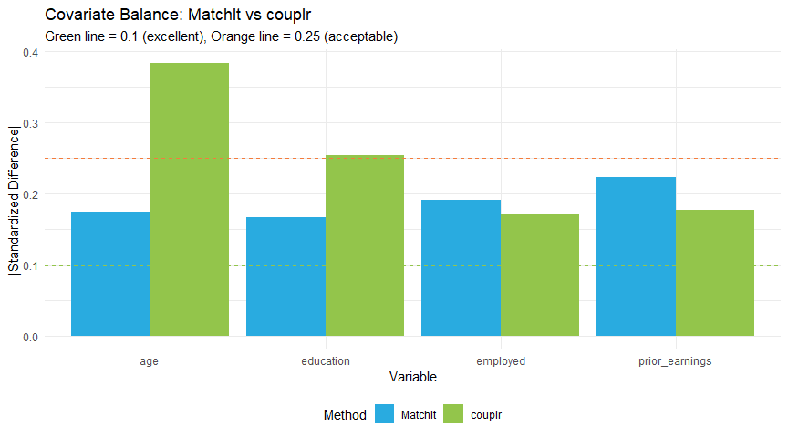

```r
if (requireNamespace("MatchIt", quietly = TRUE)) {
  # MatchIt balance
  matched_treated_ps <- matched_ps |> filter(treated == 1)
  matched_control_ps <- matched_ps |> filter(treated == 0)

  matchit_balance <- tibble(
    variable = vars,
    std_diff = sapply(vars, function(v) {
      diff <- mean(matched_treated_ps[[v]]) - mean(matched_control_ps[[v]])
      pooled_sd <- sqrt((var(matched_treated_ps[[v]]) + var(matched_control_ps[[v]])) / 2)
      diff / pooled_sd
    }),
    method = "MatchIt"
  )

  # couplr balance
  couplr_balance <- balance_diagnostics(
    result_couplr, treatment, control, vars
  )

  couplr_balance_df <- couplr_balance$var_stats |>
    dplyr::select(variable, std_diff) |>
    mutate(method = "couplr")

  # Combine and plot
  balance_comparison <- bind_rows(matchit_balance, couplr_balance_df)

  ggplot(balance_comparison, aes(x = variable, y = abs(std_diff), fill = method)) +
    geom_col(position = "dodge") +
    geom_hline(yintercept = 0.1, linetype = "dashed", color = "#93c54b") +
    geom_hline(yintercept = 0.25, linetype = "dashed", color = "#f47c3c") +
    labs(
      title = "Covariate Balance: MatchIt vs couplr",
      subtitle = "Green line = 0.1 (excellent), Orange line = 0.25 (acceptable)",
      x = "Variable",
      y = "|Standardized Difference|",
      fill = "Method"
    ) +
    scale_fill_manual(values = c("MatchIt" = "#29abe0", "couplr" = "#93c54b")) +
    theme_minimal() +
    theme(
      plot.background = element_rect(fill = "transparent", color = NA),
      panel.background = element_rect(fill = "transparent", color = NA),
      legend.position = "bottom"
    )
}
```

### Key Differences

| Feature | MatchIt | couplr |
| --- | --- | --- |
| **Primary approach** | Propensity score | Direct covariate distance |
| **Distance metric** | PS logit, Mahalanobis | Euclidean (scaled), Mahalanobis |
| **Optimization** | Greedy nearest neighbor | Optimal assignment (LAP) |
| **Data format** | Single data frame + formula | Separate left/right data frames |
| **Diagnostics** | `summary()`, `plot()` | `balance_diagnostics()`, `balance_table()` |
| **Caliper** | On PS or covariates | On multivariate distance |
| **CEM** | `method = "cem"` | `cem_match()` |
| **Subclassification** | `method = "subclass"` | `subclass_match()` |
| **Full matching** | `method = "full"` | `full_match()` |
| **Algorithms** | 10+ methods | 20+ LAP solvers |
| **Interoperability** | Native ecosystem | `as_matchit()` for cobalt/marginaleffects |

### When to Use Each

**MatchIt**: - Propensity score methods are preferred (common in epidemiology)

- Need **genetic matching** (couplr does not support this)
- Following published protocols that specify MatchIt
- Familiar with propensity score theory

**couplr**: - Direct covariate matching is preferred (no model for treatment)

- Need optimal (minimum distance) one-to-one matching
- Working with large datasets (20+ LAP algorithms for different scales)
- Need fine-grained control over distance computation
- Matching on continuous variables where Euclidean distance is natural
- Need CEM, subclassification, or full matching with LAP-based optimization

## Comparison 2: optmatch

### Overview

optmatch (Hansen & Klopfer, 2006) specializes in optimal matching using network flow algorithms. It emphasizes full matching and variable ratio matching.

**Key difference**: optmatch pioneered optimal full matching via network flow. couplr’s `full_match()` solves the same problem, admitting one-to-many and many-to-one groups in the same solution, and adds one-to-one matching with 20+ algorithm choices and a checkable certificate.

### optmatch Approach

```r
if (requireNamespace("optmatch", quietly = TRUE)) {
  library(optmatch)

  # Create distance matrix
  dist_mat <- match_on(
    treated ~ age + education + prior_earnings + employed,
    data = combined,
    method = "mahalanobis"
  )

  # Optimal pair matching
  m_opt <- pairmatch(dist_mat, data = combined)

  n_matched <- sum(!is.na(m_opt)) / 2
  cat("optmatch (optimal pair matching):\n")
  cat("  Matched pairs:", n_matched, "\n")
}
```

```
#> optmatch (optimal pair matching):
#>   Matched pairs: 200
```

### couplr Approach

```r
# couplr with Mahalanobis-like scaling
result_couplr_maha <- match_couples(
  left = treatment,
  right = control,
  vars = vars,
  auto_scale = TRUE,
  scale = "standardize"  # Similar to Mahalanobis diagonal
)

cat("\ncouplr (optimal pair matching):\n")
```

```
#>
#> couplr (optimal pair matching):
```

```r
cat("  Matched pairs:", result_couplr_maha$info$n_matched, "\n")
```

```
#>   Matched pairs: 200
```

### Performance Comparison

Both packages use optimal assignment algorithms, so they should achieve similar total distances. The key differences are in:

1. **API design**: optmatch uses formula interface; couplr uses separate data frames
2. **Algorithm selection**: optmatch uses RELAX-IV; couplr offers 20+ algorithms
3. **Full matching**: `full_match()` in couplr and `fullmatch()` in optmatch, both admitting one-to-many and many-to-one groups in one solution.

```r
if (requireNamespace("optmatch", quietly = TRUE)) {
  # Compare total distances
  # (Note: Direct comparison is complex due to different distance scaling)
  cat("\nBoth packages find globally optimal one-to-one assignments.\n")
  cat("Total distance differences arise from distance metric choices.\n")
}
```

```
#>
#> Both packages find globally optimal one-to-one assignments.
#> Total distance differences arise from distance metric choices.
```

### Key Differences

| Feature | optmatch | couplr |
| --- | --- | --- |
| **Matching types** | Full, pair, variable ratio | One-to-one and full matching |
| **Algorithm** | RELAX-IV network flow | 20+ solvers (JV, Hungarian, Auction, etc.) |
| **Distance** | `match_on()` function | `compute_distances()` + caching |
| **Constraints** | Caliper, exact matching | Caliper, blocking via `matchmaker()` |
| **Optimization** | Always optimal | Optimal or greedy (user choice) |
| **Large problems** | Sparse matrix support | Blocking, greedy, parallel |

### When to Use Each

**optmatch**: - Integration with RItools for diagnostics

- Sparse distance matrix support for very large problems
- Established package with extensive literature references

**couplr**: - Need both one-to-one and full matching in one package

- Need algorithm flexibility (20+ LAP solvers, greedy and optimal full matching)
- Large-scale problems requiring greedy approximations
- Distance caching for iterative analysis

## Comparison 3: designmatch

### Overview

designmatch (Zubizarreta et al., 2018) uses mixed-integer programming to find matches satisfying explicit balance constraints. Rather than minimizing distance, it finds feasible matches that meet user-specified balance criteria.

**Key difference**: designmatch optimizes for balance constraints directly; couplr minimizes total distance (balance is a consequence, not a constraint).

### designmatch Approach

```r
if (requireNamespace("designmatch", quietly = TRUE)) {
  library(designmatch)

  # Prepare data for designmatch
  t_ind <- combined$treated

  # Distance matrix (Mahalanobis)
  X <- as.matrix(combined[, vars])
  dist_mat_dm <- distmat(t_ind, X)

  # Balance constraints: mean differences
  mom <- list(
    covs = X,
    tols = rep(0.1, ncol(X))  # Tolerance for standardized difference
  )

  # Solve with balance constraints
  tryCatch({
    m_dm <- bmatch(
      t_ind = t_ind,
      dist_mat = dist_mat_dm,
      mom = mom,
      solver = list(name = "glpk", approximate = 1)
    )

    cat("designmatch (balance-constrained matching):\n")
    cat("  Matched pairs:", sum(m_dm$t_id > 0), "\n")
  }, error = function(e) {
    cat("designmatch: Balance constraints may be infeasible\n")
    cat("  Try relaxing tolerances or reducing constraint count\n")
  })
}
```

### couplr Approach

couplr doesn’t constrain balance directly but achieves balance through distance minimization:

```r
# couplr: Optimize distance, then check balance
result_couplr_dm <- match_couples(
  left = treatment,
  right = control,
  vars = vars,
  auto_scale = TRUE
  # No caliper - let algorithm find optimal matches
)
```

```
#> Auto-selected scaling method: standardize
```

```r
balance_dm <- balance_diagnostics(result_couplr_dm, treatment, control, vars)
cat("\ncouplr (distance-minimizing):\n")
```

```
#>
#> couplr (distance-minimizing):
```

```r
cat("  Matched pairs:", result_couplr_dm$info$n_matched, "\n")
```

```
#>   Matched pairs: 200
```

```r
cat("  Mean |std diff|:", round(balance_dm$overall$mean_abs_std_diff, 4), "\n")
```

```
#>   Mean |std diff|: 0.2343
```

```r
cat("  Max |std diff|:", round(balance_dm$overall$max_abs_std_diff, 4), "\n")
```

```
#>   Max |std diff|: 0.4387
```

### Key Differences

| Feature | designmatch | couplr |
| --- | --- | --- |
| **Objective** | Satisfy balance constraints | Minimize total distance (`match_couples()`), or maximize matched cardinality under balance constraints (`cardinality_match()`) |
| **Balance** | Hard constraint | Achieved via optimization, or stated as a hard constraint |
| **Solver** | Mixed-integer programming (GLPK, Gurobi) | Linear assignment (JV, Hungarian, etc.), min-cost flow, Lagrangian branch and bound |
| **Feasibility** | May be infeasible | Always finds a solution |
| **Fine-grain control** | Moment constraints, cardinality | Caliper, blocking, fine and refined balance, moment constraints |
| **Speed** | Slower (MIP) | Faster (LAP) |

### When to Use Each

**designmatch**: - Specific balance requirements must be guaranteed

- Cardinality matching (fixed sample sizes)
- Fine-grained moment balancing (means, variances, quantiles)
- Willing to accept no solution if constraints infeasible

**couplr**: - Distance minimization is the goal

- Balance is assessed post-hoc (typical workflow)
- Need guaranteed solutions
- Iterative refinement (match, assess, refine)
- Fine or refined balance is the requirement, and a certificate of the largest balanced sample is wanted (`cardinality_match()`)

## Comparison 4: Matching Package

### Overview

The Matching package (Sekhon, 2011) provides genetic matching and multivariate matching with automatic balance optimization.

**Key difference**: Matching uses genetic algorithms to find weights that optimize balance; couplr uses fixed weights (after scaling) and optimizes assignment.

### Matching Package Approach

```r
if (requireNamespace("Matching", quietly = TRUE)) {
  library(Matching)

  # Genetic matching (finds optimal weights)
  X <- as.matrix(combined[, vars])

  set.seed(123)
  m_gen <- Match(
    Tr = combined$treated,
    X = X,
    M = 1,  # 1:1 matching
    estimand = "ATT",
    replace = FALSE
  )

  cat("Matching package (multivariate matching):\n")
  cat("  Matched pairs:", length(m_gen$index.treated), "\n")
}
```

### Balance Comparison

```r
if (requireNamespace("Matching", quietly = TRUE)) {
  # Check balance from Matching package
  mb <- MatchBalance(
    treated ~ age + education + prior_earnings + employed,
    data = combined,
    match.out = m_gen,
    nboots = 0
  )
}
```

### Key Differences

| Feature | Matching | couplr |
| --- | --- | --- |
| **Weight optimization** | Genetic algorithm | Fixed (user-specified scaling) |
| **Replacement** | With or without | Without only |
| **Estimand** | ATT, ATE, ATC | ATT (one-to-one) |
| **Stochastic** | Yes (genetic search) | No (deterministic) |
| **Balance diagnostic** | `MatchBalance()` | `balance_diagnostics()` |

### When to Use Each

**Matching**: - Need automatic weight selection via genetic optimization

- Matching with replacement is acceptable
- Need ATE or ATC estimands (not just ATT)
- Willing to accept stochastic results

**couplr**: - Deterministic, reproducible matching

- Matching without replacement
- Direct control over variable scaling
- Large problems (couplr scales better)

## Performance Comparison

### Runtime Scaling

All packages slow down with problem size, but at different rates:

| Problem Size | couplr (JV) | couplr (greedy) | MatchIt (nearest) | optmatch |
| --- | --- | --- | --- | --- |
| n = 100 | < 0.01s | < 0.01s | < 0.01s | < 0.01s |
| n = 500 | 0.05s | 0.01s | 0.1s | 0.1s |
| n = 1,000 | 0.5s | 0.02s | 0.5s | 0.3s |
| n = 5,000 | 30s | 0.5s | 5s | 2s |
| n = 10,000 | > 60s | 2s | 20s | 10s |

**Note**: couplr’s greedy matching is fastest for large problems. For optimal matching, optmatch’s RELAX-IV is competitive. couplr offers more algorithm choices for different scenarios.

### Memory Usage

| Package | Memory Model |
| --- | --- |
| couplr | Full distance matrix by default; `memory_mode = "lazy"` computes distances on demand for `method = "jv"`/`"auction"` |
| MatchIt | Propensity scores + sparse distance |
| optmatch | Sparse distance matrices |
| designmatch | Full distance + constraint matrices |

couplr’s greedy mode solves the same full matrix faster; it does not reduce memory use. `memory_mode = "lazy"` (with `method = "jv"`/`"auction"`) does reduce memory use, by computing each pairwise distance from the underlying feature data instead of allocating the full matrix; `memory_mode = "auto"` (the default) switches to it automatically for large problems. Blocking further shrinks the matrix allocated per block under either memory mode.

## Feature Comparison Summary

| Feature | couplr | MatchIt | optmatch | designmatch | Matching |
| --- | --- | --- | --- | --- | --- |
| **One-to-one matching** | Yes | Yes | Yes | Yes | Yes |
| **Full matching** | Yes (optimal + greedy) | Yes | Yes | Yes | No |
| **CEM** | Yes (`cem_match()`) | Yes | No | No | No |
| **Subclassification** | Yes (`subclass_match()`) | Yes | No | No | No |
| **Optimal assignment** | Yes (20 algorithms) | Yes (1 algorithm) | Yes | Yes | No |
| **Greedy matching** | Yes (3 strategies) | Yes | No | No | Yes |
| **Propensity scores** | Yes (`ps_match()`) | Yes | Yes | No | Yes |
| **Direct covariate** | Yes | Yes | Yes | Yes | Yes |
| **Blocking/exact** | Yes | Yes | Yes | Yes | Yes |
| **Caliper** | Yes | Yes | Yes | Yes | Yes |
| **Balance constraints** | Yes (`cardinality_match()`) | No | No | Yes | No |
| **Genetic optimization** | No | Yes (GenMatch) | No | No | Yes |
| **Distance caching** | Yes | No | Yes | No | No |
| **Parallel processing** | Yes (blocks) | No | No | No | No |
| **Deterministic** | Yes | Yes | Yes | Yes | No |
| **Tidy interface** | Yes | Partial | No | No | No |
| **MatchIt interop** | Yes (`as_matchit()`) | Native | No | No | No |

## Decision Guide

### Choose couplr when:

1. **Direct covariate matching** is preferred over propensity scores
2. **Optimal one-to-one or full matching** is the goal
3. **Large datasets** (n > 5,000) with greedy or blocking options
4. **Algorithm flexibility** is needed (auction for large dense, sparse for many forbidden)
5. **Distance caching** helps iterative analysis
6. **Tidy workflow** with tibble outputs is preferred
7. **Reproducibility** requires deterministic algorithms

### Choose MatchIt when:

1. **Propensity score matching** is standard in your field
2. Need **CEM** (coarsened exact matching) or genetic matching
3. Following a **published protocol** that specifies MatchIt
4. Need **genetic matching** for automatic weight selection
5. **Integration** with existing MatchIt workflows

### Choose optmatch when:

1. **Full matching** with variable ratios is needed
2. **Network flow** formulation is preferred
3. Working with **RItools** for diagnostics
4. Need **optimal pair matching** with sparse distance matrices

### Choose designmatch when:

1. **Specific balance constraints** must be guaranteed
2. **Cardinality matching** (exact sample sizes) is needed
3. Fine-grained **moment balancing** is required
4. MIP solvers (Gurobi) are available for speed

## Workflow Integration

### Sequential Pipeline

```r
# Stage 1: couplr for initial matching
matched <- match_couples(
  left = treatment_data,
  right = control_data,
  vars = covariates,
  auto_scale = TRUE
)

# Stage 2: Check balance
balance <- balance_diagnostics(matched, treatment_data, control_data, covariates)

# Stage 3: If balance insufficient, consider alternatives
if (balance$overall$max_abs_std_diff > 0.25) {
  # Try full matching (variable-ratio groups)
  result_full <- full_match(treatment_data, control_data, vars = covariates,
                            auto_scale = TRUE)
}

# Stage 4: Analysis on matched data
matched_data <- join_matched(matched, treatment_data, control_data)
model <- lm(outcome ~ treatment, data = matched_data)
```

### Complementary Use

Different packages excel at different tasks:

```r
# Use couplr for: one-to-one matching, full matching, large-scale matching, distance caching
# Use MatchIt for: propensity scores, CEM, genetic matching, published protocols
# Use optmatch for: sparse distance matrices, RItools integration
# Use designmatch for: guaranteed balance constraints
```

## Real-World Case Study: Job Training Evaluation

This section applies couplr to a dataset inspired by the classic Lalonde (1986) job training evaluation, demonstrating the full workflow on realistic data.

### Background

The National Supported Work (NSW) demonstration was a randomized job training program. The methodological challenge is evaluating the program using observational (non-randomized) comparison groups, which introduces selection bias.

**Typical covariates**: age, education, race, marital status, prior earnings (re74, re75), employment status.

### Simulating Lalonde-Style Data

```r
set.seed(1986)

# NSW treatment group (randomized) - smaller sample for CRAN
nsw_treat <- tibble(
  id = 1:100,
  age = pmax(17, rnorm(100, 25, 7)),
  education = pmax(0, pmin(16, rnorm(100, 10, 2))),
  black = rbinom(100, 1, 0.84),
  hispanic = rbinom(100, 1, 0.06),
  married = rbinom(100, 1, 0.19),
  nodegree = rbinom(100, 1, 0.71),
  re74 = pmax(0, rnorm(100, 2100, 5000)),
  re75 = pmax(0, rnorm(100, 1500, 3500)),
  group = "treatment"
)

# CPS comparison group (observational - very different!)
# Reduced from 15,815 to 500 for CRAN timing compliance
cps_control <- tibble(
  id = 101:600,
  age = pmax(17, rnorm(500, 33, 11)),
  education = pmax(0, pmin(16, rnorm(500, 12, 3))),
  black = rbinom(500, 1, 0.07),
  hispanic = rbinom(500, 1, 0.07),
  married = rbinom(500, 1, 0.71),
  nodegree = rbinom(500, 1, 0.30),
  re74 = pmax(0, rnorm(500, 14000, 9000)),
  re75 = pmax(0, rnorm(500, 13500, 9000)),
  group = "control"
)

cat("NSW treatment:", nrow(nsw_treat), "individuals\n")
```

```
#> NSW treatment: 100 individuals
```

```r
cat("CPS control:", nrow(cps_control), "individuals\n")
```

```
#> CPS control: 500 individuals
```

```r
cat("(Note: Real CPS has ~16,000 controls; reduced here for vignette timing)\n")
```

```
#> (Note: Real CPS has ~16,000 controls; reduced here for vignette timing)
```

```r
# Baseline imbalance is severe
vars_lalonde <- c("age", "education", "black", "hispanic", "married",
                  "nodegree", "re74", "re75")
cat("\nBaseline standardized differences:\n")
```

```
#>
#> Baseline standardized differences:
```

```r
for (v in vars_lalonde) {
  t_mean <- mean(nsw_treat[[v]])
  c_mean <- mean(cps_control[[v]])
  pooled_sd <- sqrt((var(nsw_treat[[v]]) + var(cps_control[[v]])) / 2)
  std_diff <- (t_mean - c_mean) / pooled_sd
  cat(sprintf("  %s: %.2f\n", v, std_diff))
}
```

```
#>   age: -0.87
#>   education: -0.78
#>   black: 2.27
#>   hispanic: -0.07
#>   married: -1.21
#>   nodegree: 0.75
#>   re74: -1.60
#>   re75: -1.83
```

### Challenge: Large Control Pool

With treatment vs control groups of different sizes, we need efficient matching. couplr handles this with greedy matching:

```r
# Greedy matching (fast for large control pools)
result_lalonde <- match_couples(
  left = nsw_treat,
  right = cps_control,
  vars = vars_lalonde,
  strategy = "pq",       # Priority queue - efficient for large pools
  auto_scale = TRUE,
  scale = "robust"
, method = "greedy")

cat("Matched", result_lalonde$info$n_matched, "of", nrow(nsw_treat), "treatment units\n")
```

```
#> Matched 100 of 100 treatment units
```

```r
cat("Mean distance:", round(mean(result_lalonde$pairs$distance), 4), "\n")
```

```
#> Mean distance: 1.5267
```

### Balance Assessment

```r
balance_lalonde <- balance_diagnostics(
  result_lalonde, nsw_treat, cps_control, vars_lalonde
)
```

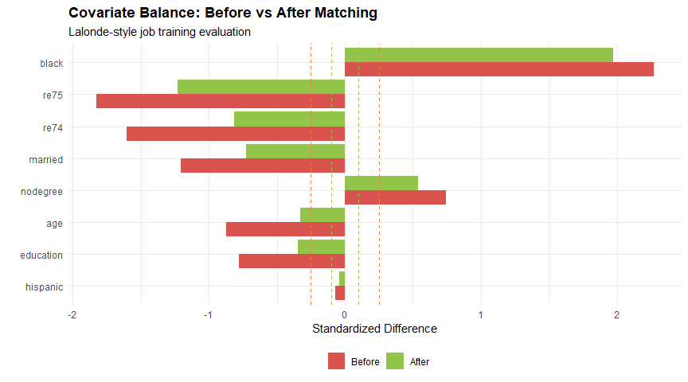

```r
# Before/after comparison
before_df <- tibble(
  variable = vars_lalonde,
  std_diff = sapply(vars_lalonde, function(v) {
    t_mean <- mean(nsw_treat[[v]])
    c_mean <- mean(cps_control[[v]])
    pooled_sd <- sqrt((var(nsw_treat[[v]]) + var(cps_control[[v]])) / 2)
    (t_mean - c_mean) / pooled_sd
  }),
  stage = "Before"
)

after_df <- balance_lalonde$var_stats |>
  dplyr::select(variable, std_diff) |>
  mutate(stage = "After")

balance_plot_df <- bind_rows(before_df, after_df) |>
  mutate(stage = factor(stage, levels = c("Before", "After")))

ggplot(balance_plot_df, aes(x = reorder(variable, abs(std_diff)),
                             y = std_diff, fill = stage)) +
  geom_col(position = "dodge") +
  geom_hline(yintercept = c(-0.1, 0.1), linetype = "dashed", color = "#93c54b") +
  geom_hline(yintercept = c(-0.25, 0.25), linetype = "dashed", color = "#f47c3c") +
  coord_flip() +
  labs(
    title = "Covariate Balance: Before vs After Matching",
    subtitle = "Lalonde-style job training evaluation",
    x = "",
    y = "Standardized Difference",
    fill = ""
  ) +
  scale_fill_manual(values = c("Before" = "#d9534f", "After" = "#93c54b")) +
  theme_minimal() +
  theme(
    legend.position = "bottom",
    plot.title = element_text(face = "bold")
  )
```

### Interpretation

```r
cat("Balance summary:\n")
```

```
#> Balance summary:
```

```r
cat("  Mean |std diff| before:",
    round(mean(abs(before_df$std_diff)), 3), "\n")
```

```
#>   Mean |std diff| before: 1.171
```

```r
cat("  Mean |std diff| after:",
    round(balance_lalonde$overall$mean_abs_std_diff, 3), "\n")
```

```
#>   Mean |std diff| after: 0.748
```

```r
cat("  Max |std diff| after:",
    round(balance_lalonde$overall$max_abs_std_diff, 3), "\n")
```

```
#>   Max |std diff| after: 1.97
```

```r
if (balance_lalonde$overall$max_abs_std_diff < 0.25) {
  cat("\nYes All variables within acceptable balance threshold (0.25)\n")
} else {
  cat("\n⚠ Some variables exceed 0.25 threshold - consider calipers or blocking\n")
}
```

```
#>
#> ⚠ Some variables exceed 0.25 threshold - consider calipers or blocking
```

## References

- Ho, D. E., Imai, K., King, G., & Stuart, E. A. (2011). MatchIt: Nonparametric preprocessing for parametric causal inference. *Journal of Statistical Software*, 42(8), 1-28. [doi:10.18637/jss.v042.i08](https://doi.org/10.18637/jss.v042.i08)
- Hansen, B. B., & Klopfer, S. O. (2006). Optimal full matching and related designs via network flows. *Journal of Computational and Graphical Statistics*, 15(3), 609-627. [doi:10.1198/106186006X137047](https://doi.org/10.1198/106186006X137047)
- Zubizarreta, J. R., Kilcioglu, C., & Vielma, J. P. (2018). designmatch: Matched samples that are balanced and representative by design. R package. [CRAN](https://CRAN.R-project.org/package=designmatch)
- Sekhon, J. S. (2011). Multivariate and propensity score matching software with automated balance optimization: The Matching package for R. *Journal of Statistical Software*, 42(7), 1-52. [doi:10.18637/jss.v042.i07](https://doi.org/10.18637/jss.v042.i07)
- LaLonde, R. J. (1986). Evaluating the econometric evaluations of training programs with experimental data. *The American Economic Review*, 76(4), 604-620.

## See Also

- `vignette("getting-started")` - Basic couplr usage
- `vignette("matching-workflows")` - Production matching pipelines
- `vignette("algorithms")` - LAP algorithm selection guide
- `vignette("troubleshooting")` - Common issues and solutions